# intro to HTS data

In this exercise will cover the following:

- File formats (FASTQ, SAM/BAM, VCF)
- Mapping (single-end, paired-end) NGS data to a reference sequence
- Read flags
- VERY IMPORTANT, you need to identify the 'pipe' button on your computer '|'. That is the character that looks like a vertical bar, on a standard American keyboard this can be found by pressing shift+'button left of enter' or 'button above enter

In this exercise you will align a fastq file using bwa and generate a SAM file.

Due to the computational time we have created a reduced genome from one of the individuals from the wildebeest project. The individual, CTauTzS_8872, has been sequenced using short read sequencing. For this exercise we have created a reduced reference genome.

The fastQ file CCTauTzS_8872.Goat.small.fq_1.gz has variable name with *_1.fq.gz which is first read or the read pair.

### running jupyter

use Ctrl+ENTER to run code.

```
DATA=/davidData/data/course/kenya2026/anders/NGSintro_day1

FASTQ_1=$DATA/CCTauTzS_8872.Goat.small.fq_1.gz
FASTQ_2=$DATA/CCTauTzS_8872.Goat.small.fq_2.gz
GOAT_REF=$DATA/goat.fa.gz

# JAVA program
PICARD=$DATA/picard.jar
echo --programs that are installed:--
which samtools
which bwa
which angsd
which bcftools
ls $PICARD

echo; echo -Datasets that will be used-
echo ---pair of fastQ files
ls $FASTQ_1
ls $FASTQ_2
echo ---reference genome with index
ls $GOAT_REF*
```

```
--programs that are installed:--
/usr/bin/samtools
/usr/bin/bwa
/usr/local/bin/angsd
/usr/bin/bcftools
/davidData/data/course/kenya2026/anders/NGSintro_day1/picard.jar

-Datasets that will be used-
---pair of fastQ files
/davidData/data/course/kenya2026/anders/NGSintro_day1/CCTauTzS_8872.Goat.small.fq_1.gz
/davidData/data/course/kenya2026/anders/NGSintro_day1/CCTauTzS_8872.Goat.small.fq_2.gz
---reference genome with index
/davidData/data/course/kenya2026/anders/NGSintro_day1/goat.fa.gz
/davidData/data/course/kenya2026/anders/NGSintro_day1/goat.fa.gz.amb
/davidData/data/course/kenya2026/anders/NGSintro_day1/goat.fa.gz.ann
/davidData/data/course/kenya2026/anders/NGSintro_day1/goat.fa.gz.bwt
/davidData/data/course/kenya2026/anders/NGSintro_day1/goat.fa.gz.fai
/davidData/data/course/kenya2026/anders/NGSintro_day1/goat.fa.gz.gzi
/davidData/data/course/kenya2026/anders/NGSintro_day1/goat.fa.gz.pac
/davidData/data/course/kenya2026/anders/NGSintro_day1/goat.fa.gz.sa
```

First make a folder for the exercise and had a symbolic link to the reference genomes and the fastQ files

```
#make folder

mkdir -p ~/kenya2026/
mkdir -p ~/kenya2026/NGSintro

# enter folder
cd ~/kenya2026/NGSintro

##make links to files and add them to the folder
# links to the two fastQ files
cp -sf  $FASTQ_1 .
cp -sf  $FASTQ_2 .
# link to reference genome
cp -sf  $GOAT_REF* .


echo --- files in folder ---
ls
```

```
--- files in folder ---
CCTauTzS_8872.Goat.small.fq_1.gz  goat.fa.gz.amb  goat.fa.gz.fai  goat.fa.gz.sa
CCTauTzS_8872.Goat.small.fq_2.gz  goat.fa.gz.ann  goat.fa.gz.gzi
goat.fa.gz                        goat.fa.gz.bwt  goat.fa.gz.pac
```

```
(work_d <- path.expand("~/kenya2026/NGSintro"))
setwd(work_d)
```

'/home/jupyter-anders/kenya2026/NGSintro'

,These are the files that you will be using.

## Mapping one reduced genome

[figure not shown]

In this exercise you will align a fastq file using bwa and generate a SAM file.

Due to the computational time we have created a reduced genome from one of the wildebeest individuals. The individual, CCTauTzS_8872, has been sequenced using Illumina short-read sequencing. For this exercise we have created a reduced reference genome consisting only of chromosome NC_030808.1

The fastQ file CCTauTzS_8872.Goat.small.fq_1.gz has variable name with *_1.fq.gz, which is the first read of the read pair. The reference genome we will map to,goat.fa.gz, also only contrains the chromosome NC_030808.1.

Before we start mapping we want to perform some QC of the data.

# step 1: FastQ file and QC

[figure not shown]

### Viewing the input files (fastQ file)

view the fastq file (CTauTzS_8872_subset_R1.fastq.gz) using the head command and identity the reads and quality scores (ignore the Broken pipe warning)

```
# -n defermines the number of lines printed
gunzip -c CCTauTzS_8872.Goat.small.fq_1.gz | head -n 12
```

```
@FP200000259BRL1C001R0010206629/1
CATACATACACAAGCATACTACACCTAGGGTGTTCTGTTTTACTATTCCTAGAGTTTGTACTTAAACACAGAGCAACACTTTTTACTGGAGAAATAGCAGACAGACACAAGATAACAATGCTTGCTTTCGTTACTTGGAGATAACATAAT
+
EFDFBFDFEFEFCEDEFFEEGEFEEEEDECDGFFFEEBDFEEFGGEDEGGFDFFCECG@GFFEFDDEGFEDDDEFFGGC@FDFEFFFECD@EEFFFDFGCFF;GEFHFGFEFFGFFGFFGAGDFFGEFD@?EGEFFGE@FDFGFFFFFGG
@FP200000259BRL1C001R0010236051/1
CCTGGCACTCACAGCGTGGCCGTTACCTCCTAGATCCTGCCAGGTCTGCTCTGAATTTAACAAGACCCTGGTGATCTGCTGGCACGTTCACACTGGAGCTGGGCTGCTTAGAGGGCGGGGTTAGTGAAGACCCCTTTCATGCGCTCCTCT
+
FGIGDEFEHGFGGFGFEFGEFIFFIGFGFGGGFGGGHGHGGFGFFEGGGGGHFFHGGHGGIHGGFFEGGFEEGEFHGEGGGFHGGGFGHHGHGGIGFHFFGFFGFFGHHHEEFEGGFFFFGDHFGGEGFCFGBEGHGGGHGFGEGFGGGG
@FP200000259BRL1C001R0010376881/1
AGGAGGCACCTCTCATGGGGCTGTCTGCGGGCTCCTCCTCTGCGGCCCTCAGCAGGGTGGGCAGGAACAGGGAGTGCTGGGTGAGCATCATGTGGACCACCGGGAGCTGGATGAGCTGCGAGCACGCGGGGCTTTCTGGGAGATACAACA
+
EEDCDDDFCFEEFEEEFCDEEEEDDEEEEFDCGECEFFFFFDEEDEEEEEFEFEECFEFCDFFFEEEFGFDEDFEEGGGFBEFDFFGFFGFFFFDDGDHEGG6FFDFGFEFFGDIFFGHGDGGFFHGGFCDFEEHFGEEEFHFFHGGHHI

gzip: stdout: Broken pipe
```

Identify the read names, the sequence, the separator line, and the base quality scores in the FASTQ output above. Then take the quiz

### run code below to start quiz

```
# run to start quiz
from jupyterquiz import display_quiz
display_quiz('https://raw.githubusercontent.com/popgenDK/courses/main/kenya2024/exercises/day1_NGSintro/quiz1.json')
```

The below command count the number of lines in the file

```
gunzip -c CCTauTzS_8872.Goat.small.fq_1.gz |  wc -l
```

```
334024
```

- How many lines to you have ????
- How many Reads in the data ????
- is the number of lines the same in the 2 fastQ files ???? ( modify the code above to see the number of lines in the other file)

Take the quiz below. press enter after entering a number

```
# run to start quiz

from jupyterquiz import display_quiz
display_quiz('https://raw.githubusercontent.com/popgenDK/courses/main/kenya2024/exercises/day1_NGSintro/quiz2.json')
```

#### reference fasta file

View the reference fasta file (goat.fa.gz) using the head command. You can modify the below uncommented code below to view other parts of the reference

```
# first 20 lines
zcat goat.fa.gz  | head -n 20

# last 1000 lines of the first million  lines (uncomment and modify below)
# gunzip -c goat.fa.gz 2>/dev/null | head -n 1000000 | tail -n 1000
```

```
>NC_030808.1
GAAGAGCCAGGAGAACTATGAgatgtcaagggaacatttcatgcaagatggccattaaag
gacagaaacaagtaaggacctaacagaagcataagatatcaagaagaggtggcaagaata
caaagaagagctATACAgaaaaaggtcttaataacctggataaccatgatagtatggtct
cacctagagcagacatcctggagtatgaagtcaagtgggccttaggaagcattactaata
aactagtggaggtgatagaattccagctgagctgtttcaaatcctaaaagatgatgctgt
taaagtgctgcactcaatatgccagcaaatttggcaaactcagcaatggccacaggactg
gaaaagtcagttttcaccccaatcccaaagaaggacaatgctgaagaatgttcaaactac
tgtacatttgcactcatttcacatgccagtaaGGAAATCCTTAAAgctggcttcagcagt
acatggacCAAGAACTTTTAGATGTgcaagctaggtttagaaaaagcagaggaaccagag
atcaaatcccttggatcacagagaaagcaagggaattccagaaaaatatccacttctgct
tcactgactacacttaaagcctttgactgtgtggatcacaacaagctgtgagaaattttt
gaagagatgagaataccaaaccatctcacctgtctcctgagaaaactgtaagtaggaaag
aaagcaacagttagaaccagacatggaacaactaagtggttcagaattgggaaaggagta
taacaaGGCTGTACACTGCCACCTTGCTTagttaacttaaatgcagagtacattatgcag
aatgccaggctggatgaatcccaagctggaatcaagattgccaggagaaatatcaacaac
ttcagatatgcagatgataccactctaatggcagaaagtgaagaggaactaaaggctCCT
CTTCAGGAGGAATAAGAGGCTCTctttagagcctcttgatgagggtgaaagagcagagtg
aaaagctggcttggaACTCAACagtaaagatcatggcatctggtcccatcactttatggc
aaatagaaggagaaaagtggTAAGcagtgaaaatttttattttcttgggctccaaaatca

gzip: stdout: Broken pipe
```

The reference contains capital and small letters. The small letter indicate that it is a repeat which can be hard to map to.

#### fastqc

lets see if there is any issues with the sequencing reads

```
fastqc --nogroup CCTauTzS_8872.Goat.small.fq_1.gz

 echo ---- fastQC has created this file ----
 ls *html
```

```
Started analysis of CCTauTzS_8872.Goat.small.fq_1.gz
Approx 5% complete for CCTauTzS_8872.Goat.small.fq_1.gz
Approx 10% complete for CCTauTzS_8872.Goat.small.fq_1.gz
Approx 15% complete for CCTauTzS_8872.Goat.small.fq_1.gz
Approx 20% complete for CCTauTzS_8872.Goat.small.fq_1.gz
Approx 25% complete for CCTauTzS_8872.Goat.small.fq_1.gz
Approx 30% complete for CCTauTzS_8872.Goat.small.fq_1.gz
Approx 35% complete for CCTauTzS_8872.Goat.small.fq_1.gz
Approx 40% complete for CCTauTzS_8872.Goat.small.fq_1.gz
Approx 45% complete for CCTauTzS_8872.Goat.small.fq_1.gz
Approx 50% complete for CCTauTzS_8872.Goat.small.fq_1.gz
Approx 55% complete for CCTauTzS_8872.Goat.small.fq_1.gz
Approx 60% complete for CCTauTzS_8872.Goat.small.fq_1.gz
Approx 65% complete for CCTauTzS_8872.Goat.small.fq_1.gz
Approx 70% complete for CCTauTzS_8872.Goat.small.fq_1.gz
Approx 75% complete for CCTauTzS_8872.Goat.small.fq_1.gz
Approx 80% complete for CCTauTzS_8872.Goat.small.fq_1.gz
Approx 85% complete for CCTauTzS_8872.Goat.small.fq_1.gz
Approx 90% complete for CCTauTzS_8872.Goat.small.fq_1.gz
Approx 95% complete for CCTauTzS_8872.Goat.small.fq_1.gz
Analysis complete for CCTauTzS_8872.Goat.small.fq_1.gz
---- fastQC has created this file ----
CCTauTzS_8872.Goat.small.fq_1_fastqc.html
```

To view the swich to the main browser tab for jypiter notebook. Enter the folder /kenya2026/NGSintro/ and find the html file. Click the file to open the fastQC report

[figure not shown]

```
# run to start quiz
from jupyterquiz import display_quiz
display_quiz('https://raw.githubusercontent.com/popgenDK/courses/main/kenya2024/exercises/day1_NGSintro/quiz3.json')
```

# mapping / Aligning

[figure not shown]

- Mapping to a reference genome
- What is in the sam/bam file?
- Quality: Mapping vs Alignment
- Sequencing Depth

Align the reads using bwa. We use bwa in the exercises because it is fast and widely used. We first need to index the reference chromosome, followed by the actual aligning process. If should take around 1 min to finish.

Once the index is made, the second step is to map the reads. There are several ways to do this, but I suggest you use the bwa mem mode, which is the most commonly used these days. Again you can run it with no arguments to get info about how to use it.

```
# see options
bwa mem
```

```
Usage: bwa mem [options] <idxbase> <in1.fq> [in2.fq]

Algorithm options:

       -t INT        number of threads [1]
       -k INT        minimum seed length [19]
       -w INT        band width for banded alignment [100]
       -d INT        off-diagonal X-dropoff [100]
       -r FLOAT      look for internal seeds inside a seed longer than {-k} * FLOAT [1.5]
       -y INT        seed occurrence for the 3rd round seeding [20]
       -c INT        skip seeds with more than INT occurrences [500]
       -D FLOAT      drop chains shorter than FLOAT fraction of the longest overlapping chain [0.50]
       -W INT        discard a chain if seeded bases shorter than INT [0]
       -m INT        perform at most INT rounds of mate rescues for each read [50]
       -S            skip mate rescue
       -P            skip pairing; mate rescue performed unless -S also in use

Scoring options:

       -A INT        score for a sequence match, which scales options -TdBOELU unless overridden [1]
       -B INT        penalty for a mismatch [4]
       -O INT[,INT]  gap open penalties for deletions and insertions [6,6]
       -E INT[,INT]  gap extension penalty; a gap of size k cost '{-O} + {-E}*k' [1,1]
       -L INT[,INT]  penalty for 5'- and 3'-end clipping [5,5]
       -U INT        penalty for an unpaired read pair [17]

       -x STR        read type. Setting -x changes multiple parameters unless overridden [null]
                     pacbio: -k17 -W40 -r10 -A1 -B1 -O1 -E1 -L0  (PacBio reads to ref)
                     ont2d: -k14 -W20 -r10 -A1 -B1 -O1 -E1 -L0  (Oxford Nanopore 2D-reads to ref)
                     intractg: -B9 -O16 -L5  (intra-species contigs to ref)

Input/output options:

       -p            smart pairing (ignoring in2.fq)
       -R STR        read group header line such as '@RG\tID:foo\tSM:bar' [null]
       -H STR/FILE   insert STR to header if it starts with @; or insert lines in FILE [null]
       -o FILE       sam file to output results to [stdout]
       -j            treat ALT contigs as part of the primary assembly (i.e. ignore <idxbase>.alt file)
       -5            for split alignment, take the alignment with the smallest coordinate as primary
       -q            don't modify mapQ of supplementary alignments
       -K INT        process INT input bases in each batch regardless of nThreads (for reproducibility) []

       -v INT        verbosity level: 1=error, 2=warning, 3=message, 4+=debugging [3]
       -T INT        minimum score to output [30]
       -h INT[,INT]  if there are <INT hits with score >80% of the max score, output all in XA [5,200]
       -a            output all alignments for SE or unpaired PE
       -C            append FASTA/FASTQ comment to SAM output
       -V            output the reference FASTA header in the XR tag
       -Y            use soft clipping for supplementary alignments
       -M            mark shorter split hits as secondary

       -I FLOAT[,FLOAT[,INT[,INT]]]
                     specify the mean, standard deviation (10% of the mean if absent), max
                     (4 sigma from the mean if absent) and min of the insert size distribution.
                     FR orientation only. [inferred]

Note: Please read the man page for detailed description of the command line and options.
```

The number of options may be a bit overwhelming, but you can run it with no additional options, although I suggest you add "-t 5" to run 5 threads if your computer has multiple cores. It reads the compressed fastq files directly, so you need not decompress them. By default the result comes on stdout (in the terminal), so you have to redirect to a file, like the below command. We also want to add a read group name with information about where the reads comes from. This is very usefull if you have sequencing data from multiple libraries.  
Now try to align the data

```
# bwa command
# bwa men -R readGroupName -t threads REF fastq_1 fast1_2

#align the data ( take ~ 1 min)
bwa mem -R '@RG\tID:foo\tSM:bar\tLB:library1' -t 5 goat.fa.gz CCTauTzS_8872.Goat.small.fq_1.gz CCTauTzS_8872.Goat.small.fq_2.gz > CTauTzS_8872.sam
```

```
[M::bwa_idx_load_from_disk] read 0 ALT contigs
[M::process] read 167012 sequences (25051800 bp)...
[M::mem_pestat] # candidate unique pairs for (FF, FR, RF, RR): (0, 73309, 10, 0)
[M::mem_pestat] skip orientation FF as there are not enough pairs
[M::mem_pestat] analyzing insert size distribution for orientation FR...
[M::mem_pestat] (25, 50, 75) percentile: (305, 328, 364)
[M::mem_pestat] low and high boundaries for computing mean and std.dev: (187, 482)
[M::mem_pestat] mean and std.dev: (337.04, 43.02)
[M::mem_pestat] low and high boundaries for proper pairs: (128, 541)
[M::mem_pestat] analyzing insert size distribution for orientation RF...
[M::mem_pestat] (25, 50, 75) percentile: (3962, 4013, 4018)
[M::mem_pestat] low and high boundaries for computing mean and std.dev: (3850, 4130)
[M::mem_pestat] mean and std.dev: (4000.00, 44.49)
[M::mem_pestat] low and high boundaries for proper pairs: (3794, 4186)
[M::mem_pestat] skip orientation RR as there are not enough pairs
[M::mem_pestat] skip orientation RF
[M::mem_process_seqs] Processed 167012 reads in 102.574 CPU sec, 20.541 real sec
[main] Version: 0.7.17-r1188
[main] CMD: bwa mem -R @RG\tID:foo\tSM:bar\tLB:library1 -t 5 goat.fa.gz CCTauTzS_8872.Goat.small.fq_1.gz CCTauTzS_8872.Goat.small.fq_2.gz
[main] Real time: 21.446 sec; CPU: 103.472 sec
```

Wait til it done - if there is not output it is still running and you will see [*]

Lets look at the generated sam file. The below command prints the first line of the file

```
# view first 1 line of the sam file
samtools view CTauTzS_8872.sam 2>/dev/null  | head -n 1
```

```
FP200000259BRL1C001R0010206629	99	NC_030808.1	760750	60	150M	=	760946	346	CATACATACACAAGCATACTACACCTAGGGTGTTCTGTTTTACTATTCCTAGAGTTTGTACTTAAACACAGAGCAACACTTTTTACTGGAGAAATAGCAGACAGACACAAGATAACAATGCTTGCTTTCGTTACTTGGAGATAACATAAT	EFDFBFDFEFEFCEDEFFEEGEFEEEEDECDGFFFEEBDFEEFGGEDEGGFDFFCECG@GFFEFDDEGFEDDDEF…
```

You can read about the sam output here: https://bioinformatics-core-shared-training.github.io/cruk-summer-school-2017/Day1/Session5-alignedReads.html

- Identify the header and explain its contents.
- For the first read identify the following and fill in the (?????) below
  - the chromosome
  - the position of the first base of the read
  - The mapping qualty
  - The alignment (cigar string)
  - the insert size (template length)
  - the read(the bases)
  - the base qualities

```
# run to start quiz
from jupyterquiz import display_quiz

display_quiz('https://raw.githubusercontent.com/popgenDK/courses/main/kenya2024/exercises/day1_NGSintro/quiz4.json')
```

Bonus information: To understand the flags (second column in the sam format) you can type a flag into this page and get the meaning: https://broadinstitute.github.io/picard/explain-flags.html

Lets try to find the number of reads in the samfile.

```
wc -l CTauTzS_8872.sam
```

```
168475 CTauTzS_8872.sam
```

- Why is it not the same number as in the fastQ file?

Fortunately there are tools to handle sam files, which will make your life easier. We will use the samtools program. First, you often need the compressed version of the sam format, which is called bam. You use samtools view for converting between formats. BAM files faciliates random access to genomic regions, but this requires the file to be sorted and requires an index this is generated using the command below. Converting sam to bam is done like this:

```
#sam to bam
samtools view -b CTauTzS_8872.sam > CTauTzS_8872.bam

#sort bam file
samtools sort -o CTauTzS_8872.sorted.bam CTauTzS_8872.bam

#index bam file
samtools index CTauTzS_8872.sorted.bam

#see files and their sizes
echo --- files sizes ---
ls -lah CTauTzS_8872.sam CTauTzS_8872.bam CTauTzS_8872.sorted.bam
```

```
--- files sizes ---
-rw-r--r-- 1 jupyter-anders jupyter-anders 30M Aug 17 07:45 CTauTzS_8872.bam
-rw-r--r-- 1 jupyter-anders jupyter-anders 73M Aug 17 07:45 CTauTzS_8872.sam
-rw-r--r-- 1 jupyter-anders jupyter-anders 24M Aug 17 07:45 CTauTzS_8872.sorted.bam
```

We now have a functional alignment file that we can use for analysis. Lets first to view the alignment at different part of the chromosome NC_030808.1. We will use tview to extact alignment. The option -d -w print 80 bases of the alignment to the terminal

```
samtools tview  CTauTzS_8872.sorted.bam  -d T -w 80 -p NC_030808.1:130171
```

```
130171    130181    130191    130201    130211    130221    130231    130241
NNNNNNNNNNNNNNNNNNNNNNNNNNNNNNNNNNNNNNNNNNNNNNNNNNNNNNNNNNNNNNNNNNNNNNNNNNNNNNNN
GACCAGTCACCCCAACATCCRTGTAGATCACAACTTCCCCTGGAGAATCTGGTGGATGCTAGAATCCTTGTGCCCCCAGA
GACCAGT                  GATCACAACTTCCCCTGGAGAATCTGGTGGATGCTAGAATCCTTGTGCCCCCAGA
ggccagtcaccccaacatccgtgtagatcacaacttcccctggagaatctggtggatgctagaatccttgtgcccccaga
GACCAGTCACCCCAACATCCATGTAGATCACAACTTCCCCTGGAGAATCTGGTGGATGCTAGAATCCTTGTGCCCCCAGA
GACCAGTCACCCCAACATCCGTGTAGATCACAACTTCCCCTGGAGAATCTGGTGGATGCTAGAATCCTTGTGCCCCCAGA
GACCAGTCACCCCAACATCCGTGTAGATCACAACTTCCCCTGGAGAATCTGGTGGATGCTAGAATCCTTGTGCCCCCAGA
gaccagtcaccccaacatccatgtagatcacaacttcccctggagaatctggtggatgctagaatccttgtgcccccaga
     gtcaccccaacatccatgtagatcacaacttcccctggagaatctggtggatgctagaatccttgtgcccccaga
     gtcaccccaacatccgtgtagatcacaacttcccctggagaatctggtggatgctagaatccttgtgcccccaga
                                 CTTCCCCTGGAGAATCTGGTGGATGCTAGAATCCTTGTGCCCCCAGA
                                                     GGATGCTAGAATCCTTGTGCCCCCAGA
```

If the above alignment looks messy then reduce the printed bases. e.g. try -w 50

In the above the lines are

Line1: The position on chromome NC_030808.1

Line2: The refence genome ( N if not provided)

Line3: The concensus sequence (If most or all reads have a G then the concensus is G)

Line4+: (lines 4,5 ect) the reads alignment

- When looking at the region starting with position NC_030808.1:130171 can you find a possible variable site?

Lets try to add the reference genome to make it easier to see the sequencing error and variable sites

```
samtools tview CTauTzS_8872.sorted.bam  -d T -w 80 -p NC_030808.1:130161 goat.fa.gz
```

```
130161    130171    130181    130191    130201    130211    130221    130231
ACACTGGTTAGACCAGTCACCCCAACATCCGTGTAGATcacaatttcccctggagaatcTGGTGGATGCTAGAATCCTTG
..............................R............C....................................
,         ,,,,,,,,,,,,,,,,,,,,a,,,,,,,,,,,,c,,,,,,,,,,,,,,,,,,,,,,,,,,,,,,,,,,,,
.................                  ........C....................................
,,,,,,,,,,,g,,,,,,,,,,,,,,,,,,,,,,,,,,,,,,,c,,,,,,,,,,,,,,,,,,,,,,,,,,,,,,,,,,,,
..............................A............C....................................
...........................................C....................................
...........................................C....................................
               ,,,,,,,,,,,,,,,a,,,,,,,,,,,,c,,,,,,,,,,,,,,,,,,,,,,,,,,,,,,,,,,,,
               ,,,,,,,,,,,,,,,,,,,,,,,,,,,,c,,,,,,,,,,,,,,,,,,,,,,,,,,,,,,,,,,,,
                                           C....................................
                                                               .................
```

- can you find the site that is likely heterozygous?

Some parts of the genome are hard to map to. Lets try another postion

- Change the position to NC_030808.1:156221. (modify above code a run)
- How many likelely variable sites can you see?
- Are these sites heterozygoes or is there another likely explanation?

Another way to look at the genome is by generating a [pileup](http://samtools.sourceforge.net/samtools.shtml) format

```
samtools mpileup CTauTzS_8872.sorted.bam -r NC_030808.1:130171-130191
```

```
[mpileup] 1 samples in 1 input files
NC_030808.1	130171	N	6	GgGGG^]g	HEGDFD
NC_030808.1	130172	N	5	AAAAa	E;DBD
NC_030808.1	130173	N	6	CcCCCc	?7HEEF
NC_030808.1	130174	N	6	CcCCCc	DEFEDD
NC_030808.1	130175	N	6	AaAAAa	GIFFDE
NC_030808.1	130176	N	7	GgGGGg^]g	lHHFFDE
NC_030808.1	130177	N	7	T$tTTTtt	g;HDD@F
NC_030808.1	130178	N	7	cCCCccc	GGEDFIF
NC_030808.1	130179	N	7	aAAAaaa	FGFDC4D
NC_030808.1	130180	N	7	cCCCccc	;GEE?HF
NC_030808.1	130181	N	7	cCCCccc	4EECFGF
NC_030808.1	130182	N	7	cCCCccc	GHEFD2F
NC_030808.1	130183	N	7	cCCCccc	CIEDFFF
NC_030808.1	130184	N	7	aAAAaaa	FFDDE4D
NC_030808.1	130185	N	7	aAAAaaa	FBDDCAG
NC_030808.1	130186	N	7	cCCCccc	GGEDEHF
NC_030808.1	130187	N	6	AAAaaa	FFFEGE
NC_030808.1	130188	N	7	tTTTttt	GFEBD6G
NC_030808.1	130189	N	7	cCCCccc	FHFE@GD
NC_030808.1	130190	N	7	cCCCccc	GGEEFFF
NC_030808.1	130191	N	7	gAGGaag	EGDEDEF
```

Each line is a position with data containing CHR, position, Reference (N if not provided), Number of reads, bases at that position and their base quality scores.

- Can you find the heterozygoes sites
- When is this a format particually usefull?

From the pileup it is easiy to get the sequencing depth distribution

```
samtools mpileup CTauTzS_8872.sorted.bam  | cut -f4 | sort -n | uniq -c >dep1

cat dep1
```

```
[mpileup] 1 samples in 1 input files
   2378 0
 219421 1
 229894 2
 312896 3
 408183 4
 464885 5
 484659 6
 448440 7
 369427 8
 280929 9
 195274 10
 124118 11
  74988 12
  42714 13
```

[output cut: 331 more lines]

the left column is the number of sites and the right is the depth.

View the distribution for this individuals using the following R command

```
depth <- read.table("dep1")
d <- 1:15 #chosen depths to plot

barplot(depth[d+1,1],names=d,xlab="sequencing depth",ylab="Number of sites with sequencing depth ",col="mistyrose")
```

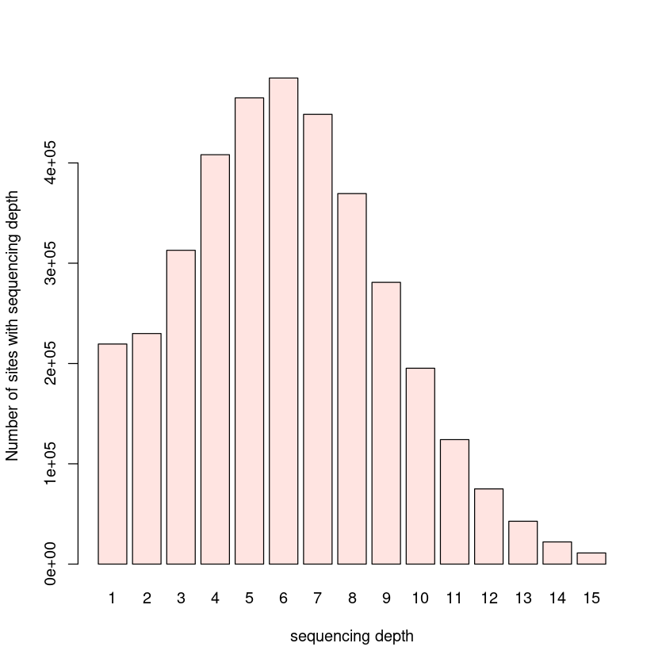

- How do you think the depth will affect genotype and variant calling?

# Variant calling

[figure not shown]

- Pileup -> variant

### create VCF file

Lets create a VCF file for the first MB of CTauTzS_8872.sorted.bam. This is done using bcftools. The ploidy is diploid (2) for mammals but otherwise we use the default settings. However, before doing so we should remove duplicated reads ( read with the same starting points) as they are likely PCR duplicate

```
## remove duplicates and index the new file
samtools rmdup -s CTauTzS_8872.sorted.bam CTauTzS_8872.md.bam
samtools index CTauTzS_8872.md.bam


## call variants
bcftools mpileup -Ou -f goat.fa.gz CTauTzS_8872.md.bam -r NC_030808.1:1-1000000 | bcftools call --ploidy 2 -mv -a GQ  -Ov -o CTauTzS_8872.vcf
```

```
[mpileup] 1 samples in 1 input files
[mpileup] maximum number of reads per input file set to -d 250
```

Lets have a look at the VCF file

```
head -n 50 CTauTzS_8872.vcf
```

```
##fileformat=VCFv4.2
##FILTER=<ID=PASS,Description="All filters passed">
##bcftoolsVersion=1.13+htslib-1.13+ds
##bcftoolsCommand=mpileup -Ou -f goat.fa.gz -r NC_030808.1:1-1000000 CTauTzS_8872.md.bam
##reference=file://goat.fa.gz
##contig=<ID=NC_030808.1,length=157403528>
##ALT=<ID=*,Description="Represents allele(s) other than observed.">
##INFO=<ID=INDEL,Number=0,Type=Flag,Description="Indicates that the variant is an INDEL.">
##INFO=<ID=IDV,Number=1,Type=Integer,Description="Maximum number of raw reads supporting an indel">
##INFO=<ID=IMF,Number=1,Type=Float,Description="Maximum fraction of raw reads supporting an indel">
##INFO=<ID=DP,Number=1,Type=Integer,Description="Raw read depth">
##INFO=<ID=VDB,Number=1,Type=Float,Description="Variant Distance Bias for filtering splice-site artefacts in RNA-seq data (bigger is better)",Version="3">
##INFO=<ID=RPBZ,Number=1,Type=Float,Description="Mann-Whitney U-z test of Read Position Bias (closer to 0 is better)">
##INFO=<ID=MQBZ,Number=1,Type=Float,Description="Mann-Whitney U-z test of Mapping Quality Bias (closer to 0 is better)">
##INFO=<ID=BQBZ,Number=1,Type=Float,Description="Mann-Whitney U-z test of Base Quality Bias (closer to 0 is better)">
##INFO=<ID=MQSBZ,Number=1,Type=Float,Description="Mann-Whitney U-z test of Mapping Quality vs Strand Bias (closer to 0 is better)">
##INFO=<ID=SCBZ,Number=1,Type=Float,Description="Mann-Whitney U-z test of Soft-Clip Length Bias (closer to 0 is better)">
##INFO=<ID=FS,Number=1,Type=Float,Description="Phred-scaled p-value using Fisher's exact test to detect strand bias">
##INFO=<ID=SGB,Number=1,Type=Float,Description="Segregation based metric.">
##INFO=<ID=MQ0F,Number=1,Type=Float,Description="Fraction of MQ0 reads (smaller is better)">
##FORMAT=<ID=PL,Number=G,Type=Integer,Description="List of Phred-scaled genotype likelihoods">
##FORMAT=<ID=GT,Number=1,Type=String,Description="Genotype">
##FORMAT=<ID=GQ,Number=1,Type=Integer,Description="Phred-scaled Genotype Quality">
##INFO=<ID=AC,Number=A,Type=Integer,Description="Allele count in genotypes for each ALT allele, in the same order as listed">
##INFO=<ID=AN,Number=1,Type=Integer,Description="Total number of alleles in called genotypes">
##INFO=<ID=DP4,Number=4,Type=Integer,Description="Number of high-quality ref-forward , ref-reverse, alt-forward and alt-reverse bases">
##INFO=<ID=MQ,Number=1,Type=Integer,Description="Average mapping quality">
##bcftools_callVersion=1.13+htslib-1.13+ds
##bcftools_callCommand=call --ploidy 2 -mv -a GQ -Ov -o CTauTzS_8872.vcf; Date=Mon Aug 17 07:45:19 2026
#CHROM	POS	ID	REF	ALT	QUAL	FILTER	INFO	FORMAT	bar
NC_030808.1	5553	.	C	G	10.7923	.	DP=1;SGB=-0.379885;FS=0;MQ0F=0;AC=2;AN=2;DP4=0,0,1,0;MQ=40	GT:PL:GQ	1/1:40,3,0:127
NC_030808.1	5580	.	A	C	5.75677	.	DP=1;SGB=-0.379885;FS=0;MQ0F=0;AC=2;AN=2;DP4=0,0,1,0;MQ=40	GT:PL:GQ	1/1:34,3,0:127
NC_030808.1	5584	.	T	G	5.75677	.	DP=2;SGB=-0.379885;FS=0;MQ0F=0;AC=2;AN=2;DP4=0,0,1,0;MQ=40	GT:PL:GQ	1/1:34,3,0:127
NC_030808.1	5600	.	A	G	8.99921	.	DP=1;SGB=-0.379885;FS=0;MQ0F=0;AC=2;AN=2;DP4=0,0,0,1;MQ=60	GT:PL:GQ	1/1:38,3,0:127
NC_030808.1	5648	.	C	T	8.13869	.	DP=1;SGB=-0.379885;FS=0;MQ0F=0;AC=2;AN=2;DP4=0,0,0,1;MQ=60	GT:PL:GQ	1/1:37,3,0:127
NC_030808.1	5657	.	G	C	8.99921	.	DP=1;SGB=-0.379885;FS=0;MQ0F=0;AC=2;AN=2;DP4=0,0,0,1;MQ=60	GT:PL:GQ	1/1:38,3,0:127
NC_030808.1	5664	.	A	G	8.99921	.	DP=1;SGB=-0.379885;FS=0;MQ0F=0;AC=2;AN=2;DP4=0,0,0,1;MQ=60	GT:PL:GQ	1/1:38,3,0:127
NC_030808.1	5685	.	G	A	44.4146	.	DP=2;VDB=0.88;SGB=-0.453602;FS=0;MQ0F=0;AC=2;AN=2;DP4=0,0,1,1;MQ=60	GT:PL:GQ	1/1:74,6,0:127
NC_030808.1	5700	.	G	A	39.4149	.	DP=2;VDB=0.86;SGB=-0.453602;FS=0;MQ0F=0;AC=2;AN=2;DP4=0,0,1,1;MQ=60	GT:PL:GQ	1/1:69,6,0:127
NC_030808.1	5739	.	C	A	7.30814	.	DP=1;SGB=-0.379885;FS=0;MQ0F=0;AC=2;AN=2;DP4=0,0,1,0;MQ=60	GT:PL:GQ	1/1:36,3,0:127
NC_030808.1	5828	.	G	T	66.4148	.	DP=3;VDB=0.17915;SGB=-0.511536;FS=0;MQ0F=0;AC=2;AN=2;DP4=0,0,2,1;MQ=60	GT:PL:GQ	1/1:96,9,0:127
NC_030808.1	5869	.	T	C	90.4151	.	DP=4;VDB=0.47843;SGB=-0.556411;MQSBZ=0.57735;FS=0;MQ0F=0;AC=2;AN=2;DP4=0,0,3,1;MQ=55	GT:PL:GQ	1/1:120,12,0:127
NC_030808.1	5878	.	gtttt	gt	28.0057	.	INDEL;IDV=2;IMF=0.5;DP=4;VDB=0.17915;SGB=-0.453602;RPBZ=0;MQBZ=1;MQSBZ=0.57735;SCBZ=-1;FS=0;MQ0F=0;AC=1;AN=2;DP4=1,0,1,1;MQ=60	GT:PL:GQ	0/1:61,0,12:10
NC_030808.1	5880	.	T	C	24.4299	.	DP=2;VDB=0.84;SGB=-0.453602;FS=0;MQ0F=0;AC=2;AN=2;DP4=0,0,2,0;MQ=50	GT:PL:GQ	1/1:54,6,0:127
NC_030808.1	5895	.	GAAAAAA	GAAAAAAA	12.6563	.	INDEL;IDV=4;IMF=1;DP=4;VDB=0.26019;SGB=-0.556411;MQSBZ=0.57735;FS=0;MQ0F=0;AC=2;AN=2;DP4=0,0,3,1;MQ=55	GT:PL:GQ	1/1:42,12,0:127
NC_030808.1	5939	.	G	C	10.7923	.	DP=5;VDB=0.14;SGB=-0.453602;FS=0;MQ0F=0;AC=2;AN=2;DP4=0,0,1,1;MQ=60	GT:PL:GQ	1/1:40,6,0:127
NC_030808.1	5953	.	G	A	35.4156	.	DP=2;VDB=0.18;SGB=-0.453602;FS=0;MQ0F=0;AC=2;AN=2;DP4=0,0,0,2;MQ=60	GT:PL:GQ	1/1:65,6,0:127
NC_030808.1	6015	.	G	A	98.4152	.	DP=4;VDB=0.26019;SGB=-0.556411;FS=0;MQ0F=0;AC=2;AN=2;DP4=0,0,1,3;MQ=60	GT:PL:GQ	1/1:128,12,0:127
NC_030808.1	6032	.	G	A	88.415	.	DP=4;VDB=0.249971;SGB=-0.556411;FS=0;MQ0F=0;AC=2;AN=2;DP4=0,0,1,3;MQ=60	GT:PL:GQ	1/1:118,12,0:127
NC_030808.1	6033	.	C	T	86.415	.	DP=4;VDB=0.27062;SGB=-0.556411;FS=0;MQ0F=0;AC=2;AN=2;DP4=0,0,1,3;MQ=60	GT:PL:GQ	1/1:116,12,0:127
```

The header of the VCF contains meta information about what it in the file. In the body of the file

- Identify the position, the reference allele and the alternative allele of the file.
- Identify the depth of each position
- Identify the genotype quality for each genotype call

There a many sites with too little information to call variants. Let apply some light filters. Here we remove sites with less than 8 reads and sites with a low quality score

```
bcftools filter CTauTzS_8872.vcf -e 'QUAL<20 || DP < 8' > CTauTzS_8872.filt.vcf

head -n 100 CTauTzS_8872.filt.vcf
```

```
##fileformat=VCFv4.2
##FILTER=<ID=PASS,Description="All filters passed">
##bcftoolsVersion=1.13+htslib-1.13+ds
##bcftoolsCommand=mpileup -Ou -f goat.fa.gz -r NC_030808.1:1-1000000 CTauTzS_8872.md.bam
##reference=file://goat.fa.gz
##contig=<ID=NC_030808.1,length=157403528>
##ALT=<ID=*,Description="Represents allele(s) other than observed.">
##INFO=<ID=INDEL,Number=0,Type=Flag,Description="Indicates that the variant is an INDEL.">
##INFO=<ID=IDV,Number=1,Type=Integer,Description="Maximum number of raw reads supporting an indel">
##INFO=<ID=IMF,Number=1,Type=Float,Description="Maximum fraction of raw reads supporting an indel">
##INFO=<ID=DP,Number=1,Type=Integer,Description="Raw read depth">
##INFO=<ID=VDB,Number=1,Type=Float,Description="Variant Distance Bias for filtering splice-site artefacts in RNA-seq data (bigger is better)",Version="3">
##INFO=<ID=RPBZ,Number=1,Type=Float,Description="Mann-Whitney U-z test of Read Position Bias (closer to 0 is better)">
##INFO=<ID=MQBZ,Number=1,Type=Float,Description="Mann-Whitney U-z test of Mapping Quality Bias (closer to 0 is better)">
##INFO=<ID=BQBZ,Number=1,Type=Float,Description="Mann-Whitney U-z test of Base Quality Bias (closer to 0 is better)">
##INFO=<ID=MQSBZ,Number=1,Type=Float,Description="Mann-Whitney U-z test of Mapping Quality vs Strand Bias (closer to 0 is better)">
##INFO=<ID=SCBZ,Number=1,Type=Float,Description="Mann-Whitney U-z test of Soft-Clip Length Bias (closer to 0 is better)">
##INFO=<ID=FS,Number=1,Type=Float,Description="Phred-scaled p-value using Fisher's exact test to detect strand bias">
##INFO=<ID=SGB,Number=1,Type=Float,Description="Segregation based metric.">
##INFO=<ID=MQ0F,Number=1,Type=Float,Description="Fraction of MQ0 reads (smaller is better)">
##FORMAT=<ID=PL,Number=G,Type=Integer,Description="List of Phred-scaled genotype likelihoods">
##FORMAT=<ID=GT,Number=1,Type=String,Description="Genotype">
##FORMAT=<ID=GQ,Number=1,Type=Integer,Description="Phred-scaled Genotype Quality">
##INFO=<ID=AC,Number=A,Type=Integer,Description="Allele count in genotypes for each ALT allele, in the same order as listed">
##INFO=<ID=AN,Number=1,Type=Integer,Description="Total number of alleles in called genotypes">
##INFO=<ID=DP4,Number=4,Type=Integer,Description="Number of high-quality ref-forward , ref-reverse, alt-forward and alt-reverse bases">
##INFO=<ID=MQ,Number=1,Type=Integer,Description="Average mapping quality">
##bcftools_callVersion=1.13+htslib-1.13+ds
##bcftools_callCommand=call --ploidy 2 -mv -a GQ -Ov -o CTauTzS_8872.vcf; Date=Mon Aug 17 07:45:19 2026
##bcftools_filterVersion=1.13+htslib-1.13+ds
##bcftools_filterCommand=filter -e 'QUAL<20 || DP < 8' CTauTzS_8872.vcf; Date=Mon Aug 17 07:45:25 2026
#CHROM	POS	ID	REF	ALT	QUAL	FILTER	INFO	FORMAT	bar
NC_030808.1	6652	.	C	G	172.416	PASS	DP=8;VDB=0.646494;SGB=-0.651104;FS=0;MQ0F=0;AC=2;AN=2;DP4=0,0,6,2;MQ=60	GT:PL:GQ	1/1:202,24,0:127
NC_030808.1	6665	.	T	G	175.416	PASS	DP=8;VDB=0.644273;SGB=-0.651104;FS=0;MQ0F=0;AC=2;AN=2;DP4=0,0,6,2;MQ=60	GT:PL:GQ	1/1:205,24,0:127
NC_030808.1	6681	.	C	G	174.416	PASS	DP=8;VDB=0.846189;SGB=-0.651104;FS=0;MQ0F=0;AC=2;AN=2;DP4=0,0,5,3;MQ=60	GT:PL:GQ	1/1:204,24,0:127
NC_030808.1	6685	.	T	C	185.416	PASS	DP=9;VDB=0.965099;SGB=-0.662043;FS=0;MQ0F=0;AC=2;AN=2;DP4=0,0,6,3;MQ=60	GT:PL:GQ	1/1:215,27,0:127
NC_030808.1	6705	.	G	A	167.416	PASS	DP=8;VDB=0.897035;SGB=-0.651104;FS=0;MQ0F=0;AC=2;AN=2;DP4=0,0,6,2;MQ=60	GT:PL:GQ	1/1:197,24,0:127
NC_030808.1	6712	.	A	G	170.416	PASS	DP=8;VDB=0.897035;SGB=-0.651104;FS=0;MQ0F=0;AC=2;AN=2;DP4=0,0,6,2;MQ=60	GT:PL:GQ	1/1:200,24,0:127
NC_030808.1	6758	.	C	A	183.416	PASS	DP=8;VDB=0.547491;SGB=-0.651104;FS=0;MQ0F=0;AC=2;AN=2;DP4=0,0,5,3;MQ=60	GT:PL:GQ	1/1:213,24,0:127
NC_030808.1	6787	.	T	A	225.417	PASS	DP=11;VDB=0.904869;SGB=-0.676189;FS=0;MQ0F=0;AC=2;AN=2;DP4=0,0,7,4;MQ=60	GT:PL:GQ	1/1:255,33,0:127
```

[output cut: 45 more lines]

```
NC_030808.1	8840	.	A	G	187.416	PASS	DP=8;VDB=0.533284;SGB=-0.651104;FS=0;MQ0F=0;AC=2;AN=2;DP4=0,0,3,5;MQ=60	GT:PL:GQ	1/1:217,24,0:127
NC_030808.1	8861	.	T	C	194.416	PASS	DP=8;VDB=0.603537;SGB=-0.651104;FS=0;MQ0F=0;AC=2;AN=2;DP4=0,0,3,5;MQ=60	GT:PL:GQ	1/1:224,24,0:127
NC_030808.1	8868	.	C	T	183.416	PASS	DP=8;VDB=0.603537;SGB=-0.651104;FS=0;MQ0F=0;AC=2;AN=2;DP4=0,0,3,5;MQ=60	GT:PL:GQ	1/1:213,24,0:127
NC_030808.1	8902	.	T	G	185.416	PASS	DP=9;VDB=0.822117;SGB=-0.662043;FS=0;MQ0F=0;AC=2;AN=2;DP4=0,0,2,7;MQ=60	GT:PL:GQ	1/1:215,27,0:127
NC_030808.1	8914	.	T	C	199.416	PASS	DP=10;VDB=0.92643;SGB=-0.670168;FS=0;MQ0F=0;AC=2;AN=2;DP4=0,0,2,8;MQ=60	GT:PL:GQ	1/1:229,30,0:127
NC_030808.1	8949	.	A	G	56.3521	PASS	DP=8;VDB=0.23997;SGB=-0.556411;RPBZ=-2.12132;BQBZ=-1.48192;SCBZ=1.32288;FS=0;MQ0F=0;AC=1;AN=2;DP4=0,3,0,4;MQ=60	GT:PL:GQ	0/1:89,0,73:74
NC_030808.1	10345	.	G	A	149.42	PASS	DP=9;VDB=0.702766;SGB=-0.662043;FS=0;MQ0F=0;AC=2;AN=2;DP4=0,0,3,6;MQ=60	GT:PL:GQ	1/1:179,24,0:127
NC_030808.1	10421	.	C	T	191.416	PASS	DP=11;VDB=0.957166;SGB=-0.676189;FS=0;MQ0F=0;AC=2;AN=2;DP4=0,0,3,8;MQ=60	GT:PL:GQ	1/1:221,33,0:127
NC_030808.1	10492	.	G	A	185.416	PASS	DP=9;VDB=0.26558;SGB=-0.662043;MQSBZ=1.74626;FS=0;MQ0F=0;AC=2;AN=2;DP4=0,0,5,4;MQ=48	GT:PL:GQ	1/1:215,27,0:127
NC_030808.1	10508	.	G	A	205.417	PASS	DP=10;VDB=0.617376;SGB=-0.670168;MQSBZ=1.92154;FS=0;MQ0F=0;AC=2;AN=2;DP4=0,0,6,4;MQ=47	GT:PL:GQ	1/1:235,30,0:127
NC_030808.1	10625	.	A	T	207.417	PASS	DP=9;VDB=0.827164;SGB=-0.662043;MQSBZ=1.34164;FS=0;MQ0F=0;AC=2;AN=2;DP4=0,0,5,4;MQ=55	GT:PL:GQ	1/1:237,27,0:127
NC_030808.1	10636	.	A	G	225.417	PASS	DP=10;VDB=0.90065;SGB=-0.670168;MQSBZ=1.49071;FS=0;MQ0F=0;AC=2;AN=2;DP4=0,0,5,5;MQ=56	GT:PL:GQ	1/1:255,30,0:127
NC_030808.1	10646	.	G	T	165.454	PASS	DP=8;VDB=0.306032;SGB=-0.651104;FS=0;MQ0F=0;AC=2;AN=2;DP4=0,0,3,5;MQ=60	GT:PL:GQ	1/1:210,36,15:127
NC_030808.1	10657	.	C	T	189.416	PASS	DP=9;VDB=0.486156;SGB=-0.662043;FS=0;MQ0F=0;AC=2;AN=2;DP4=0,0,3,6;MQ=60	GT:PL:GQ	1/1:219,27,0:127
NC_030808.1	10663	.	T	C	191.416	PASS	DP=9;VDB=0.515403;SGB=-0.662043;FS=0;MQ0F=0;AC=2;AN=2;DP4=0,0,3,6;MQ=60	GT:PL:GQ	1/1:221,27,0:127
```

- How many sites are are called as variable?
- Find a heterozygous site. ( look for 0/1)

# Bonus exercise (Only do this part if you have finished the rest)

Look at the alignment for the position

```
POS=6833

#the site you choose is the first base of the alignment so we center it by subtracting 50 to the position
POS50=$(($POS  - 50 ))
samtools tview  CTauTzS_8872.sorted.bam  -d T -w 100 -p NC_030808.1:$POS50
```

```
        6791      6801      6811      6821      6831      6841      6851      6861      6871
NNNNNNNNNNNNNNNNNNNNNNNNNNNNNNNNNNNNNNNNNNNNNNNNNNNNNNNNNNNNNNNNNNNNNNNNNNNNNNNNNNNNNNNNNNNNNNNNNNNN
AGAGAAAAAGACATGGCTCCAATCCATCCAGGAGATTTKKAGTCTGCCCTRTGAAAGGATTCTTTCCATCGACTCCCTCATGGTGCCCTGGGGGCGTGGT
AGAGAAAAA  CATGGCTCCAATCCATCCAGGAGATTT**AGTCTGCCCTGTGAAAGGATTCTTTCCATCGACTCCCTCATGGTGCCCTGGGGGCGTGGT
AGAGAAAAAGACATGG                        agtctgccctatgaaaggattctttccatcgactccctcatggtgccctgggggcgtggt
agagaaaaagacatggctccaatccatccaggag           gccctatgaaaggattctttccatcgactccctcatggtgccctgggggcgtggt
AGAGAAAAAGACATGGCTCCAATCCATCCAGGAGATTT**AGTCTGCCCTATG
AGAGAAAAAGACATGGCTCCAATCCATCCAGGAGATTT**AGTCTGCCCTATGAAAGGATTCTTTC
AGAGAAAAAGACATGGCTCCAATCCATCCAGGGGATTT**AGTCTGCCCTGTGAAAGGATTCTTTCCATCGACTCCCTCATGGTGCCCTGGGGGC
agagaaaaagacatggctccaatccatccaggagattt**agtctgccctgtgaaaggattctttccatcgactccctcatggtgccctgggggcgtggt
agagaaaaagacatggctccaatccatccaggagattt**agtctgccctgtgaaaggattctttccatcgactccctcatggtgccctgggggcgtggt
AGAGAAAAAGACATGGCTCCAATCCATCCAGGAGATTT**AGTCTGCCCTATGAAAGGATTCTTTCCATCGACTCCCTCATGGTGCCCTGGGGGCGTGGT
AGAGAAAAAGACATGGCTCCAATCCATCCAGGAGATTT**AGTCTGCCCTGTGAAAGGATTCTTTCCATCGACTCCCTCATGGTGCCCTGGGGGCGTGGT
agagaaaaagacatggctccaatccatccaggagattt**agtctgccctatgaaaggattctttccatcgactccctcatggtgccctgggggcgtggt
```

We can use the mpileup option to get a summary of the data at that position

```
echo -e "CHR\tPOS\tREF\tDEPTH\tBASES\tbaseQuality" > mpileup.file
samtools mpileup  CTauTzS_8872.sorted.bam -r NC_030808.1:$POS-$POS >> mpileup.file

echo --- pileup of the site which shows the bases and their score ---
column -t mpileup.file
```

```
[mpileup] 1 samples in 1 input files
--- pileup of the site which shows the bases and their score ---
CHR          POS   REF  DEPTH  BASES       baseQuality
NC_030808.1  6833  N    10     AAGggAGaGa  fE7IEGFFEG
```

- At that position count the number of bases of different types

# T = ??

- Calculate the genotype likelihoods and call the genotype for the site.

You can use the shiny app to help with the calculations for calculating genotype likelihoods using the GATK model. Enter the BASES and their base qualities

https://popgen.dk/shiny/anders/GL/

The resulting values will not be exactly the same as in bcftools since bcftools uses a slightly different way of calculating the genotype likelihoods than the GATK model.

# Bonus exercise (Only do this part if you have finished the rest)

## Bonus exercise 2 - duplicated reads using Picardtools

bwa actually fills in the mate information, but not all aligners do that, so we can run picard tools to fill in the mate information and sort the file according to position. We will output the file in the binary version of SAM which is BAM

```
java -jar $DATA/picard.jar FixMateInformation INPUT=CTauTzS_8872.sam \
OUTPUT=id.fixmate.srt.bam SORT_ORDER=coordinate
```

[output not shown]

View the header of the BAM file

```
samtools view -H id.fixmate.srt.bam
```

```
@HD	VN:1.6	SO:coordinate
@SQ	SN:NC_030808.1	LN:157403528
@RG	ID:foo	SM:bar	LB:library1
@PG	ID:bwa	PN:bwa	VN:0.7.17-r1188	CL:bwa mem -R @RG\tID:foo\tSM:bar\tLB:library1 -t 5 goat.fa.gz CCTauTzS_8872.Goat.small.fq_1.gz CCTauTzS_8872.Goat.small.fq_2.gz
@PG	ID:samtools	PN:samtools	PP:bwa	VN:1.13	CL:samtools view -H id.fixmate.srt.bam
```

picard didn't update the PG flag, so let us update the header information so that we have documented how we modified the file.

```
(samtools view -H id.fixmate.srt.bam;echo -e "@PG\tID:fixmate\tPN:fixmate\tVN:2.60\tCL:stuff" ) >newhd
samtools reheader newhd id.fixmate.srt.bam > id.fixmate.srt2.bam
```

- Validate that the header in file id.fixmate.srt2.bam has been updated

```
samtools view -H id.fixmate.srt2.bam
```

```
@HD	VN:1.6	SO:coordinate
@SQ	SN:NC_030808.1	LN:157403528
@RG	ID:foo	SM:bar	LB:library1
@PG	ID:bwa	PN:bwa	VN:0.7.17-r1188	CL:bwa mem -R @RG\tID:foo\tSM:bar\tLB:library1 -t 5 goat.fa.gz CCTauTzS_8872.Goat.small.fq_1.gz CCTauTzS_8872.Goat.small.fq_2.gz
@PG	ID:samtools	PN:samtools	PP:bwa	VN:1.13	CL:samtools view -H id.fixmate.srt.bam
@PG	ID:fixmate	PN:fixmate	VN:2.60	CL:stuff
@PG	ID:samtools.1	PN:samtools	PP:samtools	VN:1.13	CL:samtools reheader newhd id.fixmate.srt.bam
@PG	ID:samtools.2	PN:samtools	PP:samtools.1	VN:1.13	CL:samtools view -H id.fixmate.srt2.bam
```

Now mark duplicates using picard

```
java -jar $DATA/picard.jar MarkDuplicates I=id.fixmate.srt2.bam \
O=id.fixmate.srt.md.bam  M=metrics;
```

[output not shown]

- Did picard update the PG flag of the header?
- Did picard update anything else in the header?

NB you can view the header of a bamfile using 'samtools view -H'

```
samtools view -H id.fixmate.srt.md.bam
```

```
@HD	VN:1.6	SO:coordinate
@SQ	SN:NC_030808.1	LN:157403528
@RG	ID:foo	SM:bar	LB:library1
@PG	ID:bwa	PN:bwa	VN:0.7.17-r1188	CL:bwa mem -R @RG\tID:foo\tSM:bar\tLB:library1 -t 5 goat.fa.gz CCTauTzS_8872.Goat.small.fq_1.gz CCTauTzS_8872.Goat.small.fq_2.gz
@PG	ID:samtools	PN:samtools	PP:bwa	VN:1.13	CL:samtools view -H id.fixmate.srt.bam
@PG	ID:fixmate	PN:fixmate	VN:2.60	CL:stuff
@PG	ID:samtools.1	PN:samtools	PP:samtools	VN:1.13	CL:samtools reheader newhd id.fixmate.srt.bam
@PG	ID:MarkDuplicates	VN:2.19.0-SNAPSHOT	CL:MarkDuplicates INPUT=[id.fixmate.srt2.bam] OUTPUT=id.fixmate.srt.md.bam METRICS_FILE=metrics    MAX_SEQUENCES_FOR_DISK_READ_ENDS_MAP=50000 MAX_FILE_HANDLES_FOR_READ_ENDS_MAP=8000 SORTING_COLLECTION_SIZE_RATIO=0.25 TAG_DUPLICATE_SET_MEMBERS=false REMOVE_SEQ…
@PG	ID:samtools.2	PN:samtools	PP:samtools.1	VN:1.13	CL:samtools view -H id.fixmate.srt.md.bam
```

## Bonus exercise 3 - clean you bam files using the FLAGS column

The second column in the SAM format is the very important FLAG. This will tell tell you about the state of the paired end mapping, QC duplicates etc.

Using the samtools -F/-f you can discard/include flags that fulfill certain patterns. See http://broadinstitute.github.io/picard/explain-flags.html .

1. How many reads have we marked as duplicate in the final file.
2. How many properly mapped read pairs do we have? (Where both reads map to the same chr etc).
3. How many mapped reads do we have ?
4. How many unmapped reads do we have ?
5. Find the distribution of the RNAMES of the unmapped reads!?

Run the following command one at a time by uncommenting them

```
#samtools view -f 1024 id.fixmate.srt.md.bam|wc -l
#samtools view -f 2 id.fixmate.srt.md.bam|wc -l
#samtools view -F 4 id.fixmate.srt.md.bam|wc -l
#samtools view -f 4 id.fixmate.srt.md.bam|wc -l
# samtools view -f 4 id.fixmate.srt.md.bam|cut -f3|sort -n |uniq -c
```

Compare with "samtools flagstat" command

```
samtools flagstat id.fixmate.srt.md.bam
```

```
168472 + 0 in total (QC-passed reads + QC-failed reads)
167012 + 0 primary
0 + 0 secondary
1460 + 0 supplementary
2 + 0 duplicates
2 + 0 primary duplicates
168472 + 0 mapped (100.00% : N/A)
167012 + 0 primary mapped (100.00% : N/A)
167012 + 0 paired in sequencing
83506 + 0 read1
83506 + 0 read2
165216 + 0 properly paired (98.92% : N/A)
167012 + 0 with itself and mate mapped
0 + 0 singletons (0.00% : N/A)
0 + 0 with mate mapped to a different chr
0 + 0 with mate mapped to a different chr (mapQ>=5)
```

Make a new bamfile, where you only the reads where both ends maps, and filter out those with a mapping quality below 10, and removing duplicates

```
samtools view -f 2 -F 1024 id.fixmate.srt.md.bam -q 10 >new.bam
```